# labbook_151222

Steve Harris

30 Dec 2015

Approach to the analysi fo the European septic shock data

We have 736 cases from 8 sites.

```
##            hosp   n pct
## 1:       Leuven 100  14
## 2:         GSTT  40   5
## 3:        Paris 100  14
## 4:      Belfast 100  14
## 5: Royal London  89  12
## 6:         UCLH 107  15
## 7:         Rome 100  14
## 8:       Ancona 100  14
```

We set relatively strict and clear inclusion criteria so the cases should be homogeneous with similar characteristics *across* sites. In particular, mortality, physiology (heart rate and blood pressure), and use of noradrenaline should not differ much.

But this is not true for mortality at either unit or hospital level.

### Mortality

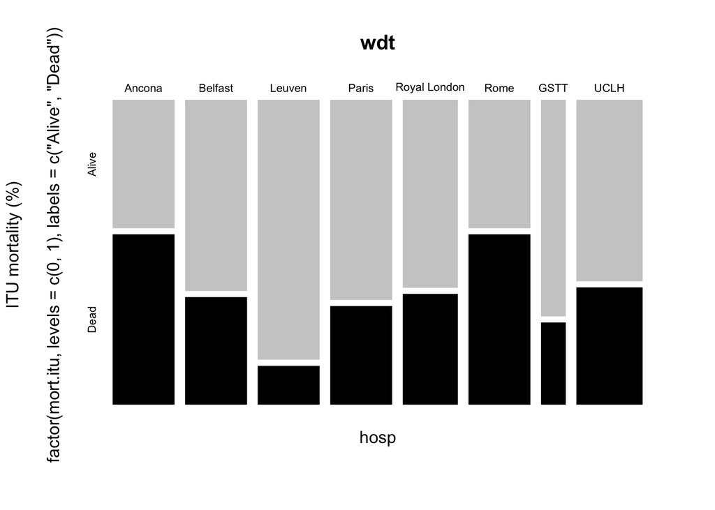

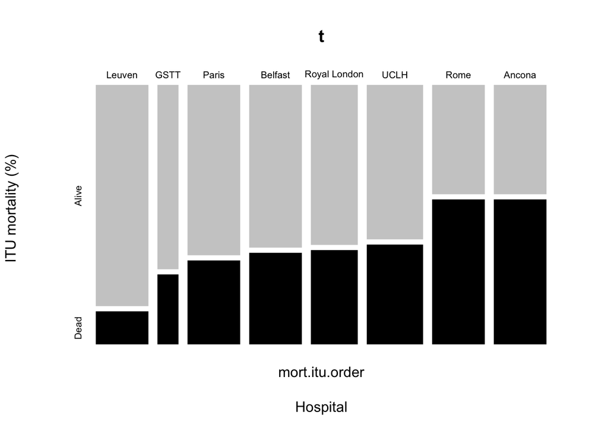

So if mortality differs, do we see a corresponding pattern in the physiology? Let’s examine heart rate for a starter.

### Heart rate

```
## [1] "Heart rate at hour 1"
```

```
##    Min. 1st Qu.  Median    Mean 3rd Qu.    Max.
##    33.0    85.0   101.0   101.4   117.0   178.0
```

```
## [1] "Heart rate at hour 24"
```

```
##    Min. 1st Qu.  Median    Mean 3rd Qu.    Max.    NA's
##    0.00   82.00   96.00   96.67  109.00  162.00      46
```

[output not shown]

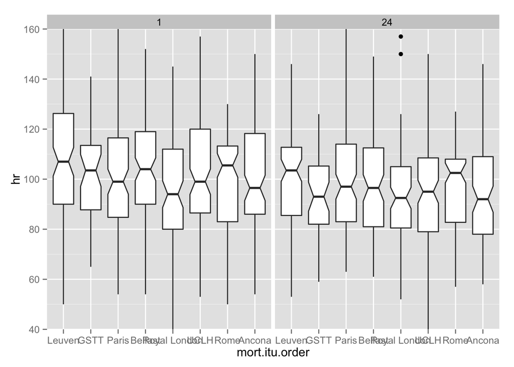

So Leuven has high mean HR and Anconca a low which gives the impression that there is an inverse relationship with mortality. But if you remove these two sites then it is less clear.

```
##
##       Ancona      Belfast       Leuven        Paris Royal London
##          100          100          100          100           89
##         Rome         GSTT         UCLH
##          100           40          107
```

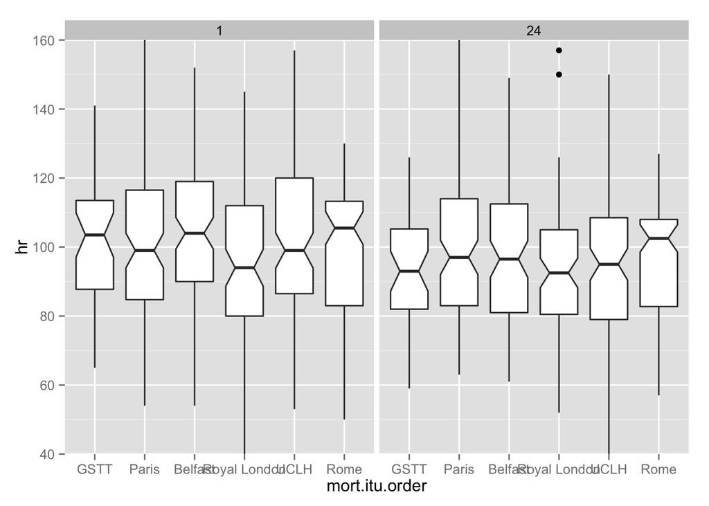

### Mean arterial pressure

Let’s check and look at Mean Arterial Pressure.

```
## [1] "MAP at hour 1"
```

```
##    Min. 1st Qu.  Median    Mean 3rd Qu.    Max.    NA's
##   32.00   61.00   69.00   69.06   76.00  117.00       4
```

```
## [1] "MAP at hour 24"
```

```
##    Min. 1st Qu.  Median    Mean 3rd Qu.    Max.    NA's
##   38.00   67.00   72.00   73.09   78.00  144.00      49
```

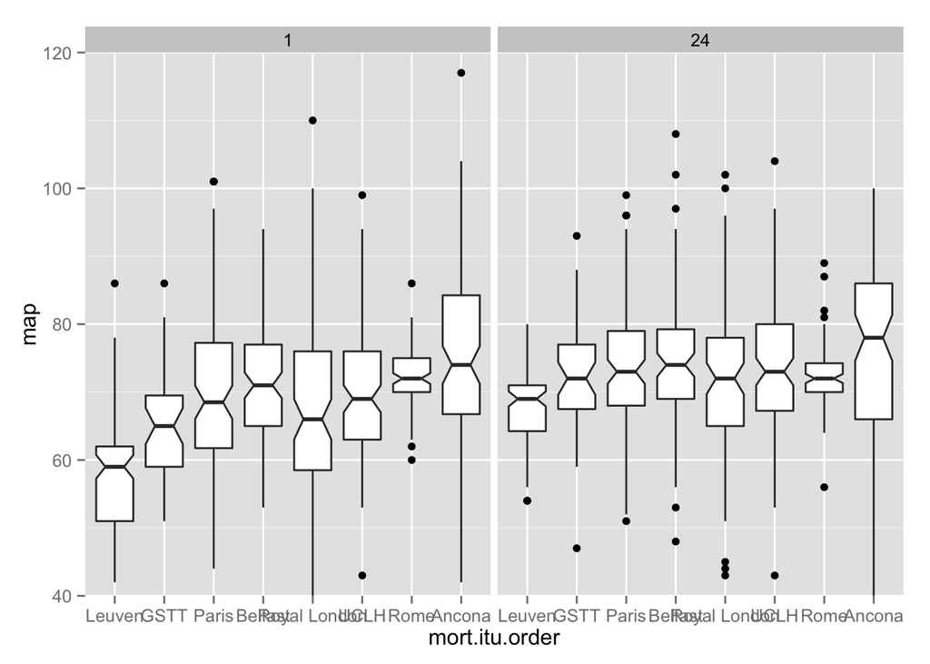

So this looks more interesting? Higher MAPs are seen in the sites with the highest ITU mortality at both hour 1 and 24.

Is this driven by noradrenaline use?

### Noradrenaline use

```
## [1] "Noradrenaline at hour 1"
```

```
##    Min. 1st Qu.  Median    Mean 3rd Qu.    Max.    NA's
##  0.0100  0.1000  0.1800  0.3079  0.3808  3.7500       6
```

```
## [1] "Noradrenaline at hour 24"
```

```
##    Min. 1st Qu.  Median    Mean 3rd Qu.    Max.    NA's
##  0.0000  0.0400  0.1780  0.3317  0.4960  4.7000      51
```

```
## notch went outside hinges. Try setting notch=FALSE.
```

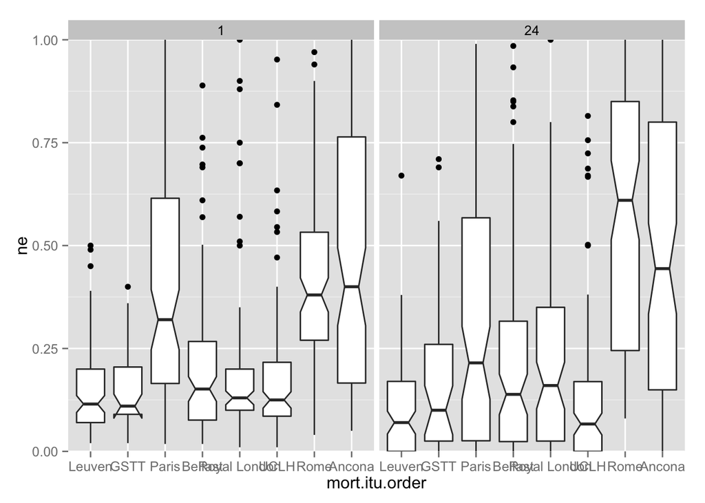

It looks like MAP and noradrenaline dose are correlated, but Paris seems to be an exception here as the noradrenaline does is high but the mortality is lowish.

Is there any chance that this might be due to different methods for calculating noradrenaline dose (dividing by ideal vs actual body weight?)

Now have a look at fluid balance and sedation practice.

### Fluid balance

```
## [1] "Fluid balance in 1st 24 h"
```

```
##    Min. 1st Qu.  Median    Mean 3rd Qu.    Max.    NA's
##   -4200    1011    1871    2450    3301   17400      12
```

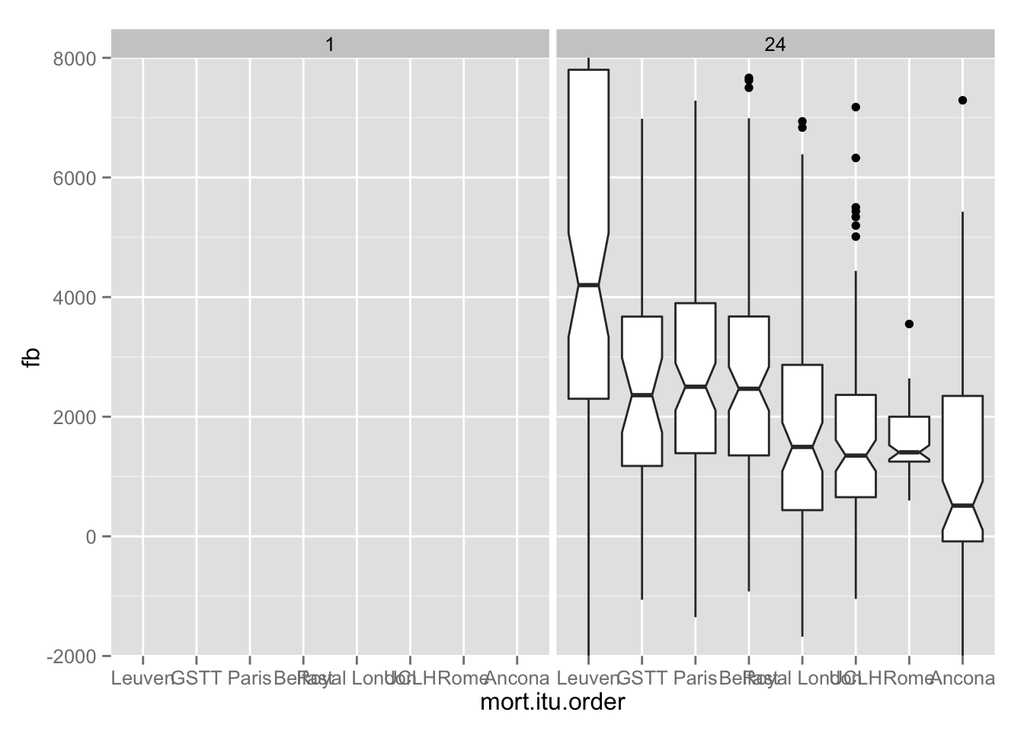

### Sedation scores

```
## [1] "Sedation scores by site"
```

```
##    mort.itu.order
##     Leuven GSTT Paris Belfast Royal London UCLH Rome Ancona
##   0     24   16    25      44           33   57    7     17
##   1      7    0     0       9            1    4    3     10
##   2      8    3     3      30           28   11    7     25
##   3      3    0     2       9            2    3    8     10
##   4     15    2    20       6            5   14   40     16
##   5     28    9    19       2            4    9   28     10
##   6     11    7     7       0           11    5    6     10
##   7      2    1    16       0            4    4    0      2
##   8      1    0     4       0            0    0    0      0
##   9      1    0     0       0            1    0    1      0
```

```
## wdt$sedation.1
##       n missing  unique    Info    Mean     .05     .10     .25     .50
##     730       6      10    0.96   2.745    0.00    0.00    0.00    2.00
##     .75     .90     .95
##    5.00    6.00    6.55
##
##             0  1   2  3   4   5  6  7 8 9
## Frequency 223 34 115 37 118 109 57 29 5 3
## %          31  5  16  5  16  15  8  4 1 0
```

```
## wdt$sedation.24
##       n missing  unique    Info    Mean     .05     .10     .25     .50
##     683      53      11    0.96   2.697       0       0       0       3
##     .75     .90     .95
##       5       6       6
##
##             0  1  2  3   4   5  6  7 8 9 10
## Frequency 203 64 55 62 118 107 51 18 3 1  1
## %          30  9  8  9  17  16  7  3 0 0  0
```

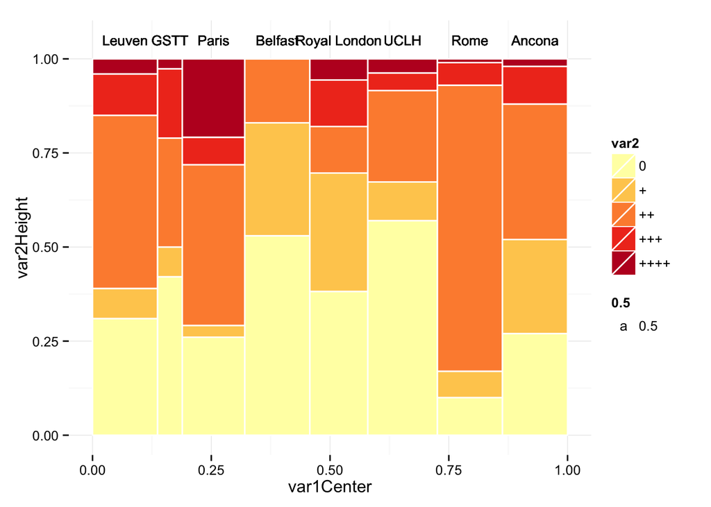

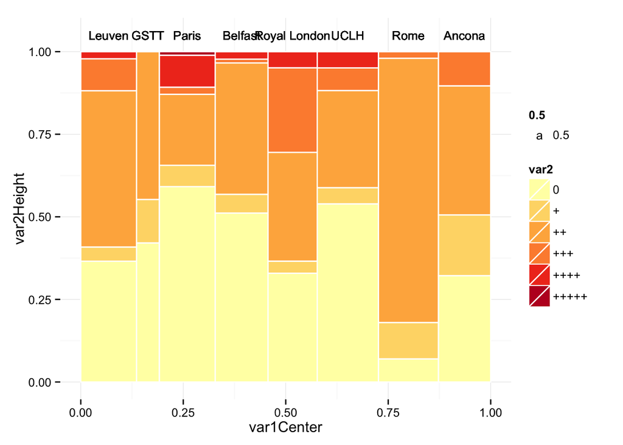

I note that Paris uses a lot of sedation which perhaps explains the higher noradrenaline requirements?